# Regression Assignment 1

Kristin Gmunder

11/7/2018

### 1. Create a Regression Repository on GitHub

Just like we did for the bootstrap module, create a repository on GitHub to store our work on regression. Call it `BST650_Regression` or something similar.

### 2. Primer on Partial Derivatives

Complete the following exercises. Turn in the work for 2 (the worked derivatives) to me next class on paper.

1. Work through this Khan Academy article (stop at the “A more formal definition” section): https://www.khanacademy.org/math/multivariable-calculus/multivariable-derivatives/partial-derivative-and-gradient-articles/a/introduction-to-partial-derivatives
2. Find both the partial derivatives (with respect to $\mu$ and $\sigma$) of the normal log-likelihood
   $$\log(L(\mu, \sigma | \textbf{x})) = \sum_{i = 1}^n \log\left( \frac{1}{\sqrt{2\pi\sigma^2}} \exp\left[ -\frac{(x_i - \mu)^2}{2\sigma^2} \right] \right).$$
   Set these partial derivatives equal to zero, and solve for $\mu$ and $\sigma$. Do you recognize these formulas?

### 3. Calculate Univariate Regression Estimates

Consider on the simple linear regression model we covered in class:

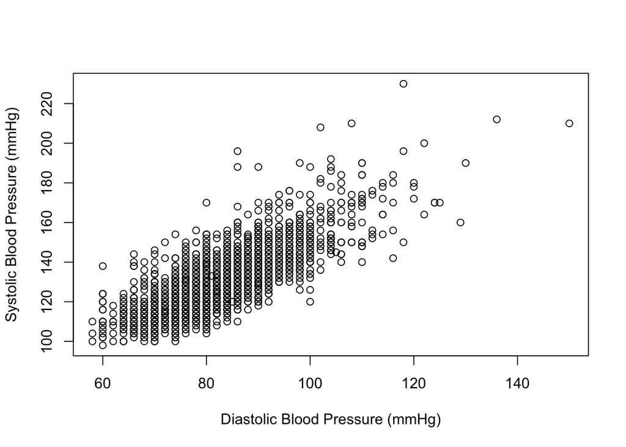

```r
wcgs_df <- read.csv("/Users/KristinGmunder/Documents/wcgs.csv", header = TRUE, stringsAsFactors = FALSE)

plot(
  x = wcgs_df$dbp,
  y = wcgs_df$sbp,
  xlab = "Diastolic Blood Pressure (mmHg)",
  ylab = "Systolic Blood Pressure (mmHg)"
)
```

```r
lm(sbp ~ dbp, data = wcgs_df)
```

```
##
## Call:
## lm(formula = sbp ~ dbp, data = wcgs_df)
##
## Coefficients:
## (Intercept)          dbp
##      30.110        1.201
```

Based on this model output, the slope ($\beta_1$) is approximately 1.2, while the intercept ($\beta_0$) is about 30.1.

Write a function which takes in any two numeric vectors (`x` and `y`) and returns a named vector of the slope and intercept of the linear model $\hat{\textbf{y}} = \beta_0 + \beta_1\textbf{x}$. Your function should use formulas (from your other classes) to calculate these estimates directly (that is, without a call to the `lm()` or any other modelling function in R).

```r
findTheBetas <- function(x, y) {
betaOne <- (cov(x,y)/var(x))
betaZero <- (mean(y)- (betaOne)*mean(x))
return(c(beta0 = betaZero, beta1 = betaOne))
}

findTheBetas(wcgs_df$dbp, wcgs_df$sbp)
```

```
##     beta0     beta1
## 30.110196  1.201268
```